# Healthcare Fraud Detection

Marko Konte

6/26/2019

## Paper Analysis: Predicting Healthcare Fraud in Medicaid: A Multidimensional Data Model and Analysis Techniques for Fraud Detection

The researches in the paper outlines a very broad, theoritcal overview of helathcare fraud and the factors which may cause it to happen. It was a good paper in laying out domain knowledge specific factors for readers to understand why healthcare fraud occurs. They explain the relationship between the main purpotrators of fraud (providers, patients, insurance carriers), the types of fraud (single large transactions or many little ones) and the 7 levelsof fraud within Sparrows model, from the lowest level being an individual fraudulent claim to level 7 being a cross- network conspiracy of fraud. An interesting point in the paper is that it highlightss that current fraud detection primarily focuses on levels 1-3. For its own model, the paper articulates its dimensionality and explains how a good analyst would take their time to look at a case starting from a low level (on sparrows chart) and moving up to wider group analysis. It will not be useful to apply level 7 analysis to a claim you are beggining to analyze due to there being too much noise in the info. If the analyst is able to detect connection between purpotrators in levels 1-3, they can move on to applying higher level analysis to determin if there is a larger network of fraud.

While the paper does a good job on a theoretical and high end explanation of healthcare fraud approach, there was not much detail in the actual analytical models that are used for the determination. THe paper strsses that it is a ‘roadmap’ for connecting to fraud, however they do not talk about what type of statistical approaches are most useful in detecting fraud from identified variables accross all 7 levels. The paper stresses that one problem in the industry is a lack of training data (marked fraudulent claims), therefore the study of healthcare fraud is a constant work in progress.

##EDA: Predicting Healthcare Fraud

```r
library(dplyr)
```

```r
#library(DataExplorer)
#library(xda)
library(ggplot2)
library(plotly)
library(data.table)
library(zipcode)
suppressPackageStartupMessages(library(tidyverse))
library(stringr)
library(ggthemes)
#install.packages('rlang')
#install.packages('maps')
suppressPackageStartupMessages(library(maps))

data(zipcode)
nrow(zipcode)
```

```
## [1] 44336
```

```r
zipcode$city <- as.factor(zipcode$city)
zipcode$state <- as.factor(zipcode$state)

payment <- read.csv("inpatientCharges.csv")

payment <- payment %>%
  mutate(Average.Covered.Charges = as.numeric(Average.Covered.Charges),
         Average.Total.Payments = as.numeric(Average.Total.Payments),
         Average.Medicare.Payments = as.numeric(Average.Medicare.Payments))

summary(payment$Total.Discharges)
```

```
##    Min. 1st Qu.  Median    Mean 3rd Qu.    Max.
##   11.00   17.00   27.00   42.78   49.00 3383.00
```

```r
summary(payment$Average.Covered.Charges)
```

```
##    Min. 1st Qu.  Median    Mean 3rd Qu.    Max.
##       1   39730   79541   79804  119796  160236
```

#Lead

First I focused on total payments and how they relate to different elements of data. First, total payments were looked at from a state perspective, then took into accounts payments per discharge, and finally I identified the standard deviation in the total payments data to discern both zip codes and states most prevalent.

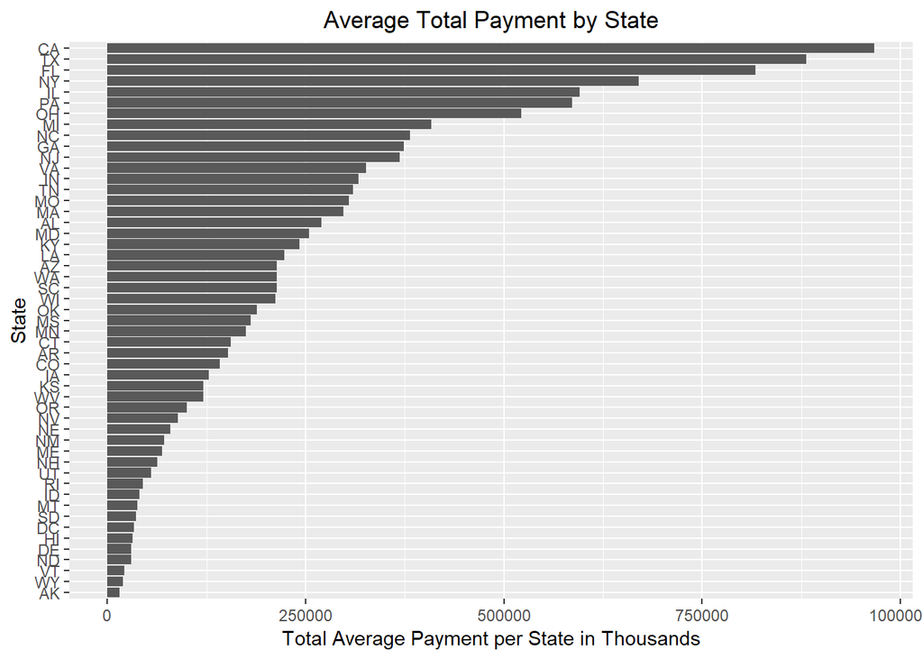

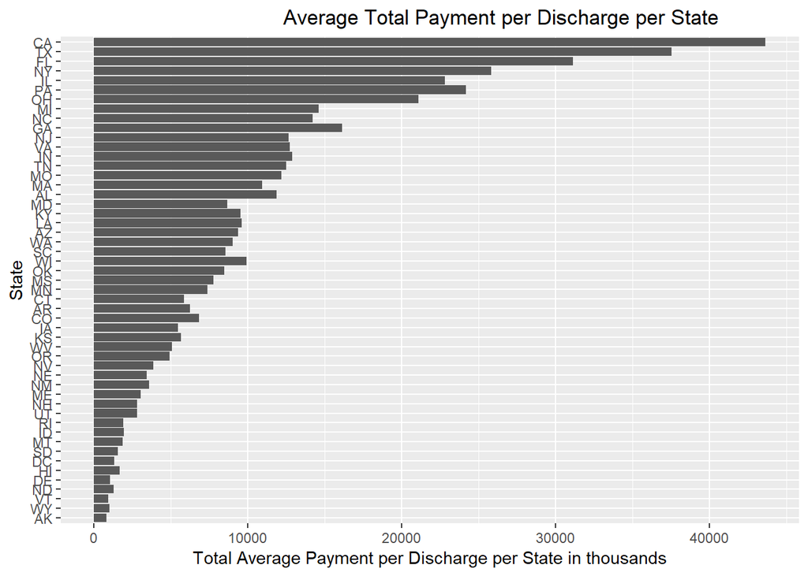

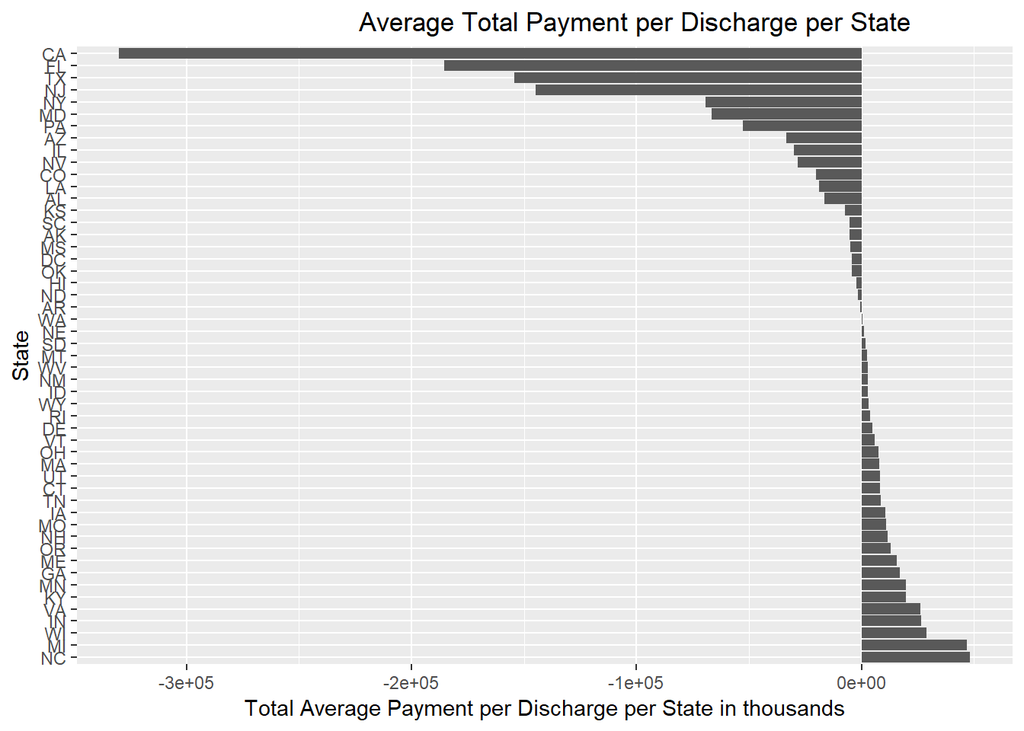

```
## # A tibble: 6 x 8
## # Groups:   DRGState [6]
##   DRGState        Provider.Zip.Co~ Count TotPay TotCov TotMed TotDis     SD
##   <chr>                      <int> <int>  <dbl>  <dbl>  <dbl>  <int>  <dbl>
## 1 TX_251 - PERC ~            75701     2 147467 150183 280928    191 1.04e5
## 2 NJ_065 - INTRA~             8901     2 148415 284718 279814    115 1.04e5
## 3 ME_698 - OTHER~             4240     2 146988 152938 286151     28 1.03e5
## 4 AR_682 - RENAL~            72401     2 149501 139263 288488    119 1.03e5
## 5 TX_418 - LAPAR~            75093     2 149252 230822 260248     24 1.03e5
## 6 TX_308 - CARDI~            78539     2 148468 222429 289661     49 1.03e5
```

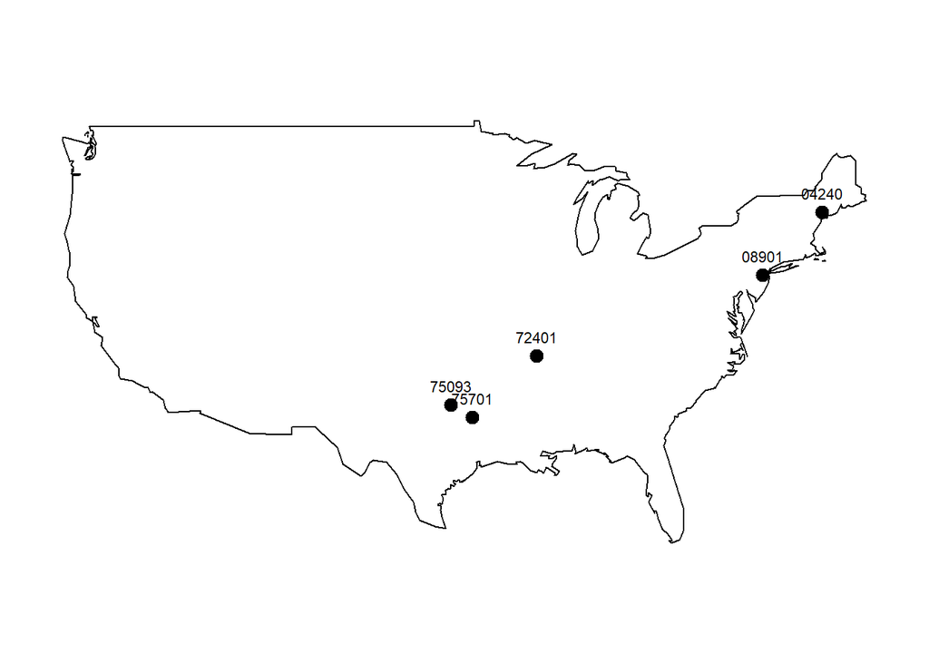

```
## # A tibble: 10 x 7
##    DRGState                       Count  TotPay TotCov TotMed TotDis     SD
##    <chr>                          <int>   <dbl>  <dbl>  <dbl>  <int>  <dbl>
##  1 AR_418 - LAPAROSCOPIC CHOLECY~    13 1043510 1.35e6 1.64e6    282 72562.
##  2 NV_482 - HIP & FEMUR PROCEDUR~    10  615155 1.39e6 1.12e6    216 72449.
##  3 MS_418 - LAPAROSCOPIC CHOLECY~    11  901153 1.07e6 1.54e6    221 71813.
##  4 MN_482 - HIP & FEMUR PROCEDUR~     8  467222 6.59e5 8.32e5    139 70941.
##  5 IA_418 - LAPAROSCOPIC CHOLECY~    10  897108 1.02e6 1.11e6    169 70388.
##  6 OK_418 - LAPAROSCOPIC CHOLECY~    14  922889 1.51e6 1.54e6    253 70048.
##  7 AL_251 - PERC CARDIOVASC PROC~    15 1059309 1.78e6 1.69e6    379 69884.
##  8 NM_482 - HIP & FEMUR PROCEDUR~     9  751600 8.59e5 9.77e5    159 69752.
##  9 AL_249 - PERC CARDIOVASC PROC~    21 1783917 2.44e6 2.50e6    787 69247.
## 10 KS_064 - INTRACRANIAL HEMORRH~    15 1098108 1.50e6 1.44e6    521 69187.
```

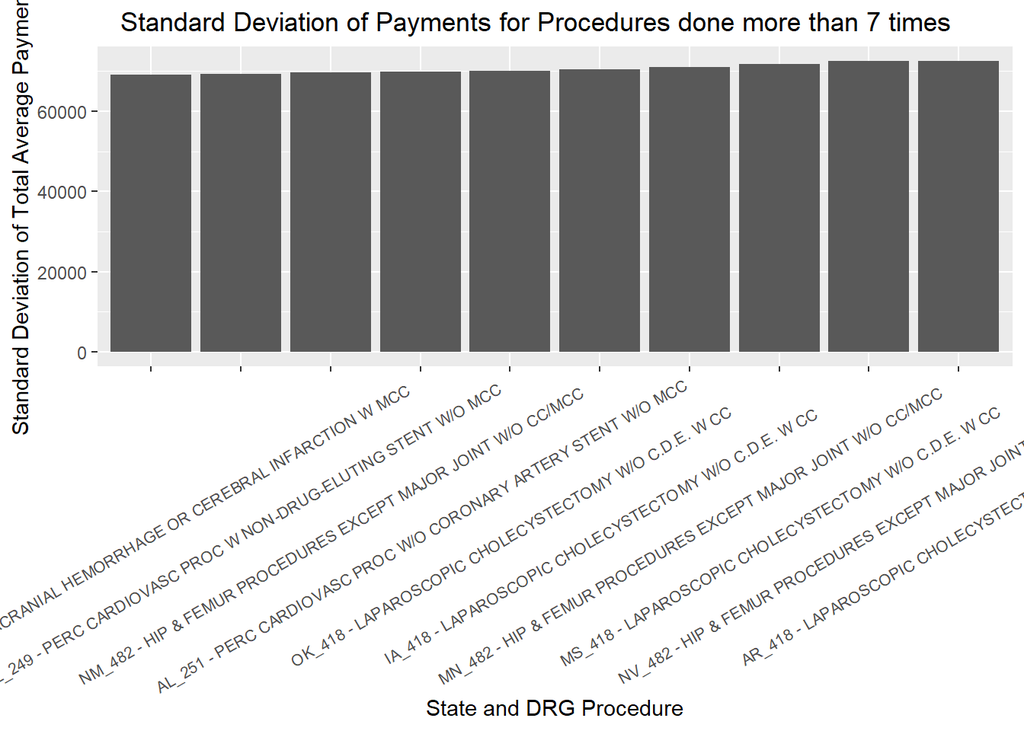

Conclusion:

As anticipated total payments was heavily influenced by the population of the given states. It was interesting that the standard the total payment per discharge by a procedure was also very heavy on the most populous states. This is either due to the expenses in those states being larger or that the discharge to procedure ratio is steady throughout the dataset.The standard deviation of total average payments will be useful in determining the procedures which have the greatest variance in how much was paid for them, which will be an important red flag for identifying healthcare fraud.